# analyse_jesse

# Regressie

```r
# willen bepalen welke var meest invloed heeft.
#cat(colnames(data))

# situaties splitten
data$id_row <- 1:nrow(data)

situaties_long <- data %>%
  select(id_row, situaties) %>%
  separate_rows(situaties, sep = ";")

situaties_long <- situaties_long %>%
  filter(situaties != "")

situaties_wide <- situaties_long %>%
  mutate(value = 1) %>%
  pivot_wider(
    names_from = situaties,
    values_from = value,
    values_fill = 0
  )

data2 <- data %>%
  left_join(situaties_wide, by = "id_row")

model = lm(score ~ leeftijd + opleiding + d_grens +
               woonwerk_duits + fam_kennis + gebruik_hoevaak +
               vakantie + werk + boodschappen + `(social) media` + overig + interesse_taal + interesse_duits,
           data = data2)

#head(data)
levels(data2$gebruik_hoevaak)
```

```
## [1] "nooit"      "regelmatig" "soms"       "vaak"
```

```r
res <- tidy(model)
summary(model)
```

```
##
## Call:
## lm(formula = score ~ leeftijd + opleiding + d_grens + woonwerk_duits +
##     fam_kennis + gebruik_hoevaak + vakantie + werk + boodschappen +
##     `(social) media` + overig + interesse_taal + interesse_duits,
##     data = data2)
##
## Residuals:
##      Min       1Q   Median       3Q      Max
## -1.46707 -0.32939 -0.02944  0.37400  1.77826
##
## Coefficients:
##                            Estimate Std. Error t value Pr(>|t|)
## (Intercept)               -1.251640   0.518333  -2.415 0.017106 *
## leeftijd40+                0.624259   0.109247   5.714  6.9e-08 ***
## opleidinghavo              0.235385   0.462190   0.509 0.611399
## opleidinghbo               0.393279   0.445803   0.882 0.379271
## opleidingmbo               0.300359   0.457180   0.657 0.512327
## opleidingvmbo              0.750809   0.514056   1.461 0.146495
## opleidingvwo               0.845788   0.498486   1.697 0.092090 .
## opleidingwo                0.772657   0.450386   1.716 0.088574 .
## d_grens                    0.002123   0.001034   2.052 0.042090 *
## woonwerk_duitsnee          0.085168   0.211053   0.404 0.687200
## fam_kennisnee             -0.079066   0.122424  -0.646 0.519497
## gebruik_hoevaakregelmatig  0.816046   0.240221   3.397 0.000899 ***
## gebruik_hoevaaksoms        0.246139   0.131246   1.875 0.062929 .
## gebruik_hoevaakvaak        0.727559   0.395481   1.840 0.068045 .
## vakantie                   0.049476   0.114817   0.431 0.667232
## werk                       0.011442   0.140371   0.082 0.935160
## boodschappen               0.030330   0.152413   0.199 0.842569
## `(social) media`           0.434437   0.167007   2.601 0.010338 *
## overig                     0.142278   0.154225   0.923 0.357921
## interesse_taalnee          0.030805   0.123395   0.250 0.803244
## interesse_duitsnee        -0.183182   0.115751  -1.583 0.115900
## ---
## Signif. codes:  0 '***' 0.001 '**' 0.01 '*' 0.05 '.' 0.1 ' ' 1
##
## Residual standard error: 0.5985 on 133 degrees of freedom
## Multiple R-squared:  0.5316, Adjusted R-squared:  0.4612
## F-statistic: 7.549 on 20 and 133 DF,  p-value: 6.362e-14
```

```r
arrange(res, estimate)
```

```
## # A tibble: 21 × 5
##    term               estimate std.error statistic p.value
##    <chr>                 <dbl>     <dbl>     <dbl>   <dbl>
##  1 (Intercept)        -1.25      0.518     -2.41    0.0171
##  2 interesse_duitsnee -0.183     0.116     -1.58    0.116
##  3 fam_kennisnee      -0.0791    0.122     -0.646   0.519
##  4 d_grens             0.00212   0.00103    2.05    0.0421
##  5 werk                0.0114    0.140      0.0815  0.935
##  6 boodschappen        0.0303    0.152      0.199   0.843
##  7 interesse_taalnee   0.0308    0.123      0.250   0.803
##  8 vakantie            0.0495    0.115      0.431   0.667
##  9 woonwerk_duitsnee   0.0852    0.211      0.404   0.687
## 10 overig              0.142     0.154      0.923   0.358
## # ℹ 11 more rows
```

```r
vif(model)
```

```
##                      GVIF Df GVIF^(1/(2*Df))
## leeftijd         1.265172  1        1.124799
## opleiding        2.130519  6        1.065059
## d_grens          1.226538  1        1.107492
## woonwerk_duits   1.880514  1        1.371318
## fam_kennis       1.332587  1        1.154377
## gebruik_hoevaak  4.763013  3        1.297120
## vakantie         1.408239  1        1.186693
## werk             1.487630  1        1.219684
## boodschappen     1.401362  1        1.183791
## `(social) media` 1.523330  1        1.234232
## overig           1.643996  1        1.282184
## interesse_taal   1.388037  1        1.178150
## interesse_duits  1.420315  1        1.191770
```

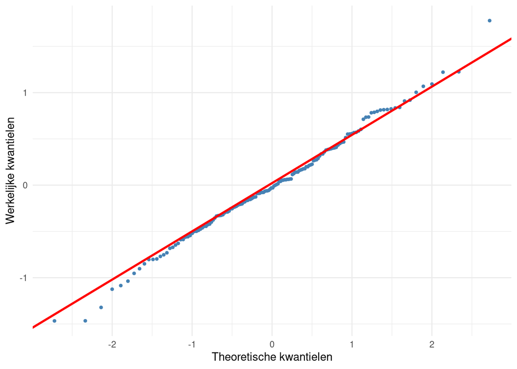

QQ-plot van residuen regressiemodel

```r
#figuur laatste?
ggplot(data = data.frame(resid = resid(model)), aes(sample = resid)) +
    stat_qq(color = "steelblue", size = 1) +
    stat_qq_line(color = "red", linewidth = 1) +
    labs(x = "Theoretische kwantielen", y = "Werkelijke kwantielen") +
    theme_minimal()
```

Leeftijd bleek een sterke voorspeller van de Duitse taalvaardigheid. Respondenten van 40 jaar en ouder scoorden gemiddeld 0.62 theta (p < .001) hoger dan respondenten in de leeftijdsgroep 18-40. Daarnaast hing regelmatig gebruik van de Duitse taal positief samen met taalvaardigheid: gemiddeld 0.81 theta (p < .001) hoger gescoord dan respondenten die aangaven de Duitse taal nooit te gebruiken. Ook gebruik van Duits in (social) media was een significante voorspeller ($\beta\approx$ 0.434, p $\approx$ 0.010). Verder werd een klein maar significant effect gevonden in de relatie tussen de score en de afstand tot de Duitse grens ($\beta\approx$ 0.002, p $\approx$ 0.042). Er werd een positieve trend gevonden voor hoger onderwijs (e.g. VWO/WO), maar deze effecten waren niet statistisch significant in het complete model.